# Project 1: Basic Reproducibility and Reporting

Stats 20, Spring 2026, Section 2

Nicole Pasternak

April 2026

Abstract

This report demonstrates reproducible data analysis using R Markdown. All results, including tables and figures, are generated directly from code. This ensures transparency, accuracy, and reproducibility.

# Introduction

This report presents a reproducible data analysis conducted using R Markdown. By integrating code, output, and written explanation within a single document, the analysis ensures full transparency and consistency. All tables, figures, and results are generated directly from the underlying code, minimizing the risk of error and enhancing reproducibility. This approach reflects best practices in data analysis by allowing the entire workflow to be easily verified and replicated.

# Question A

- Statistical modeling and probability
- Economic decision-making and behavioral analysis.

I am consistently drawn to statistical modeling and economics because they provide structured frameworks for understanding uncertainty and human behavior. Statistical methods allow me to analyze patterns in data and make informed predictions, while economic theory helps explain how individuals and markets respond to incentives and constraints. Together, these areas offer powerful tools for interpreting complex real-world problems and making evidence-based decisions.

# Question B

The following code demonstrates how to load the `pokemon.RData` file and examine the structure of the data frame it contains. Inspecting the structure allows us to understand the variables, their data types, and the overall organization of the dataset.

```r
# Load dataset into R environment for analysis
load("pokemon.RData")

# Identify loaded object
ls()
```

```
## [1] "pokemon_df"
```

```r
# Assign to 'pokemon' for consistency
pokemon <- get(ls()[1])

# Display structure
str(pokemon)
```

```
## Classes 'tbl_df', 'tbl' and 'data.frame':    949 obs. of  22 variables:
##  $ id             : num  1 2 3 4 5 6 7 8 9 10 ...
##  $ pokemon        : chr  "bulbasaur" "ivysaur" "venusaur" "charmander" ...
##  $ species_id     : num  1 2 3 4 5 6 7 8 9 10 ...
##  $ height         : num  0.7 1 2 0.6 1.1 1.7 0.5 1 1.6 0.3 ...
##  $ weight         : num  6.9 13 100 8.5 19 90.5 9 22.5 85.5 2.9 ...
##  $ base_experience: num  64 142 236 62 142 240 63 142 239 39 ...
##  $ type_1         : chr  "grass" "grass" "grass" "fire" ...
##  $ type_2         : chr  "poison" "poison" "poison" NA ...
##  $ hp             : num  45 60 80 39 58 78 44 59 79 45 ...
##  $ attack         : num  49 62 82 52 64 84 48 63 83 30 ...
##  $ defense        : num  49 63 83 43 58 78 65 80 100 35 ...
##  $ special_attack : num  65 80 100 60 80 109 50 65 85 20 ...
##  $ special_defense: num  65 80 100 50 65 85 64 80 105 20 ...
##  $ speed          : num  45 60 80 65 80 100 43 58 78 45 ...
##  $ color_1        : chr  "#78C850" "#78C850" "#78C850" "#F08030" ...
##  $ color_2        : chr  "#A040A0" "#A040A0" "#A040A0" NA ...
##  $ color_f        : chr  "#81A763" "#81A763" "#81A763" NA ...
##  $ egg_group_1    : chr  "monster" "monster" "monster" "monster" ...
##  $ egg_group_2    : chr  "plant" "plant" "plant" "dragon" ...
##  $ url_icon       : chr  "//archives.bulbagarden.net/media/upload/7/7b/001MS6.png" "//archives.bulbagarden.net/media/upload/a/a0/002MS6.png" "//archives.bulbagarden.net/media/upload/0/07/003MS6.png" "//archives.bulbagarden.net/media/upload/7/7d/004MS6.png" ...
##  $ generation_id  : num  1 1 1 1 1 1 1 1 1 1 ...
##  $ url_image      : chr  "https://raw.githubusercontent.com/HybridShivam/Pokemon/master/assets/images/001.png" "https://raw.githubusercontent.com/HybridShivam/Pokemon/master/assets/images/002.png" "https://raw.githubusercontent.com/HybridShivam/Pokemon/master/assets/images/003.png" "https://raw.g…
```

# Question C

The following visualization explores the relationship between two key Pokemon attributes: attack and defense. A scatterplot is used to help identify whether there is any visible pattern or relationship between offensive and defensive strength across different Pokemon.

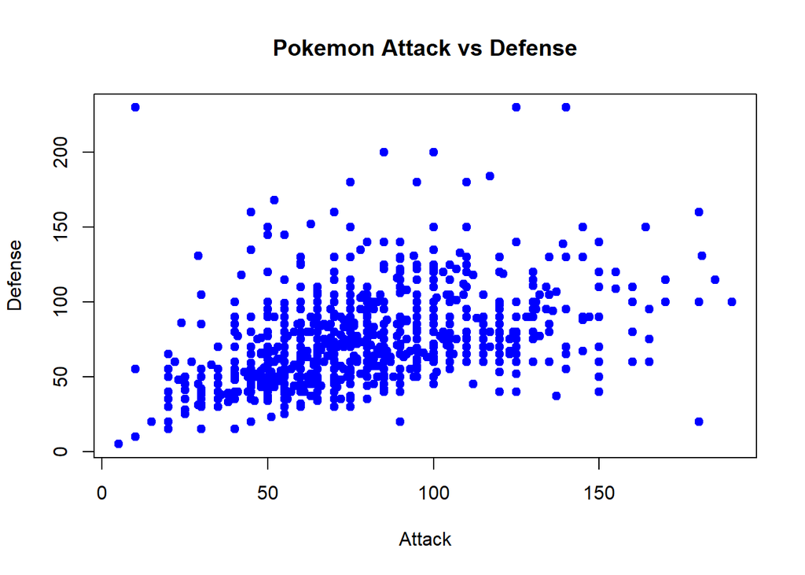

```r
# Simple scatterplot showing relationship between attack and defense
plot(pokemon$attack, pokemon$defense,
     main = "Pokemon Attack vs Defense",
     xlab = "Attack",
     ylab = "Defense",
     pch = 19,
     col = "blue")
```

# Question D

While the scatterplot provides a visual understanding of the relationship between attack and defense, it is also important to examine the dataset using numerical summaries. Summary statistics and data previews allow us to understand the overall structure, central tendencies, and variability of the variables in a more precise way. The following code generates a quick view of the dataset along with key descriptive statistics.

```r
# Preview first observations to verify column structure and data format
head(pokemon, 10)
```

```
##    id    pokemon species_id height weight base_experience type_1 type_2 hp
## 1   1  bulbasaur          1    0.7    6.9              64  grass poison 45
## 2   2    ivysaur          2    1.0   13.0             142  grass poison 60
## 3   3   venusaur          3    2.0  100.0             236  grass poison 80
## 4   4 charmander          4    0.6    8.5              62   fire   <NA> 39
## 5   5 charmeleon          5    1.1   19.0             142   fire   <NA> 58
## 6   6  charizard          6    1.7   90.5             240   fire flying 78
## 7   7   squirtle          7    0.5    9.0              63  water   <NA> 44
## 8   8  wartortle          8    1.0   22.5             142  water   <NA> 59
## 9   9  blastoise          9    1.6   85.5             239  water   <NA> 79
## 10 10   caterpie         10    0.3    2.9              39    bug   <NA> 45
##    attack defense special_attack special_defense speed color_1 color_2 color_f
## 1      49      49             65              65    45 #78C850 #A040A0 #81A763
## 2      62      63             80              80    60 #78C850 #A040A0 #81A763
## 3      82      83            100             100    80 #78C850 #A040A0 #81A763
```

[output cut: 40 more lines]

```r
# Compute descriptive statistics for all variables to assess distributions and ranges
summary(pokemon)
```

```
##        id          pokemon            species_id        height
##  Min.   :    1   Length:949         Min.   :  1.0   Min.   : 0.100
##  1st Qu.:  238   Class :character   1st Qu.:191.0   1st Qu.: 0.500
##  Median :  475   Mode  :character   Median :395.0   Median : 1.000
##  Mean   : 1900                      Mean   :400.1   Mean   : 1.228
##  3rd Qu.:  712                      3rd Qu.:615.0   3rd Qu.: 1.500
##  Max.   :10147                      Max.   :802.0   Max.   :14.500
##
##      weight       base_experience    type_1             type_2
##  Min.   :  0.10   Min.   : 36.0   Length:949         Length:949
##  1st Qu.:  8.50   1st Qu.: 68.0   Class :character   Class :character
##  Median : 28.80   Median :157.0   Mode  :character   Mode  :character
##  Mean   : 66.21   Mean   :150.5
##  3rd Qu.: 66.60   3rd Qu.:184.0
##  Max.   :999.90   Max.   :608.0
##
##        hp             attack          defense       special_attack
##  Min.   :  1.00   Min.   :  5.00   Min.   :  5.00   Min.   : 10.00
##  1st Qu.: 50.00   1st Qu.: 55.00   1st Qu.: 50.00   1st Qu.: 50.00
##  Median : 65.00   Median : 75.00   Median : 70.00   Median : 65.00
##  Mean   : 68.95   Mean   : 79.47   Mean   : 74.07   Mean   : 72.81
##  3rd Qu.: 80.00   3rd Qu.:100.00   3rd Qu.: 90.00   3rd Qu.: 95.00
##  Max.   :255.00   Max.   :190.00   Max.   :230.00   Max.   :194.00
##
##  special_defense      speed          color_1            color_2
##  Min.   : 20.00   Min.   :  5.00   Length:949         Length:949
##  1st Qu.: 50.00   1st Qu.: 45.00   Class :character   Class :character
##  Median : 70.00   Median : 65.00   Mode  :character   Mode  :character
##  Mean   : 72.22   Mean   : 69.02
##  3rd Qu.: 90.00   3rd Qu.: 90.00
##  Max.   :230.00   Max.   :180.00
##
##    color_f          egg_group_1        egg_group_2          url_icon
##  Length:949         Length:949         Length:949         Length:949
##  Class :character   Class :character   Class :character   Class :character
##  Mode  :character   Mode  :character   Mode  :character   Mode  :character
##
##
##
##
##  generation_id    url_image
##  Min.   :1.000   Length:949
##  1st Qu.:2.000   Class :character
##  Median :4.000   Mode  :character
##  Mean   :3.695
##  3rd Qu.:5.000
##  Max.   :7.000
##  NA's   :147
```

# Question E

```r
# Download image locally
download.file(
  "https://raw.githubusercontent.com/PokeAPI/sprites/master/sprites/pokemon/25.png",
  destfile = "pikachu.png",
  mode = "wb"
)

# Show image from local file
knitr::include_graphics("pikachu.png")
```

[output not shown]

# Question F

To further explore the dataset, we shift from visual representation to quantitative analysis by extracting a numeric variable and computing a summary statistic.

```r
# Extract HP as a numeric vector
hp_vector <- pokemon$hp

# Compute mean HP (ignore missing values)
mean(hp_vector, na.rm = TRUE)
```

```
## [1] 68.95469
```

# Question G

Building on this summary statistic, we next examine how vectorized operations can be applied to the same type of numeric data to transform and manipulate values efficiently across the entire dataset.

```r
# Extract attack vector
attack_vector <- pokemon$attack

# Operation 1: add constant to each value
attack_plus_10 <- attack_vector + 10

# Operation 2: Log transformation applied to entire attack column
log_attack <- log(attack_vector)

# Show results
head(data.frame(attack_vector, attack_plus_10, log_attack))
```

```
##   attack_vector attack_plus_10 log_attack
## 1            49             59   3.891820
## 2            62             72   4.127134
## 3            82             92   4.406719
## 4            52             62   3.951244
## 5            64             74   4.158883
## 6            84             94   4.430817
```